# Capsule 2 - Comprendre la saturation

MQT-2101 - Analyse et modélisation des données

## Pourquoi ça compte

Un ralentissement des ventes prouve-t-il un manque de capacité?

La capacité, l’attente et les ruptures de stock peuvent éclairer le contexte. Un graphique ne permet pas d’isoler leur effet causal.

## Objectifs de la capsule

- Relier un indice au contexte.
- Interpréter un taux d’occupation.
- Distinguer courbure et plateau.

## Trois indices à examiner

Capacité

achalandage rapporté à une référence

Attente

temps moyen, en minutes

Stock

nombre de ruptures observées

## Un taux peut dépasser 100 %

$$\text{Taux d’occupation}=\frac{\text{achalandage}}{\text{capacité de référence}}$$

2 400 visites pour une référence de 2 000 : 1,20, soit 120 %. Ce rapport n’est pas une probabilité.

## Observer l’attente

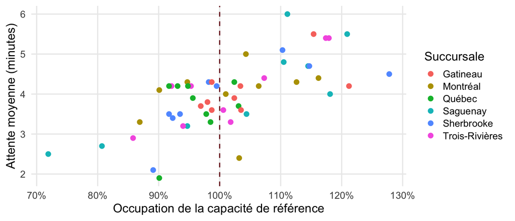

## Ralentissement et plateau

- Ralentissement : la hausse devient plus faible.
- Plateau : la courbe se rapproche d’une limite.
- Un ralentissement observé ne démontre pas un plafond.

Une courbe quadratique peut redescendre. Un logarithme croissant n’a pas de plafond.

## Confronter plusieurs explications

Hypothèse : davantage de visites met le service sous pression.

- Autres facteurs : saison, marketing, taille du magasin.
- Les mêmes succursales reviennent chaque mois.
- Comparer des associations ne remplace pas un plan causal.

## Logarithmique et logistique

Ventes

réponse quantitative : module 4

Oui / non

réponse binaire : module 10

Log(x)

transformation d’une explicative positive

Le modèle logarithmique étudié ici prédit des dollars. La régression logistique modélise une probabilité.

## À retenir

Indice

une information de contexte

Hypothèse

une explication à confronter

Plateau

une limite non démontrée

## Production autonome 4.2

Choisissez un indice parmi le taux d’occupation, l’attente et les ruptures de stock. Décrivez ce qu’il mesure, une hypothèse opérationnelle et une autre explication possible.

### Auto-vérification

- J’ai distingué un taux d’occupation d’une probabilité.
- Mon hypothèse reste à vérifier.
- Je ne confonds pas courbure et preuve de saturation.